# Prediction Assignment Writeup

Jessie

# Background

Using devices such as Jawbone Up, Nike FuelBand, and Fitbit it is now possible to collect a large amount of data about personal activity relatively inexpensively. These type of devices are part of the quantified self movement - a group of enthusiasts who take measurements about themselves regularly to improve their health, to find patterns in their behavior, or because they are tech geeks. One thing that people regularly do is quantify how much of a particular activity they do, but they rarely quantify how well they do it.

More information is available from the website here: http://groupware.les.inf.puc-rio.br/har (see the section on the Weight Lifting Exercise Dataset).

The goal of this project is to predict the manner in which the participants did the exercise. This is the “classe” variable of the training set, which classifies the correct and incorrect outcomes into A, B, C, D, and E categories. This report describes how the model for the project was built, its cross validation, expected out of sample error calculation, and the choices made.

# Data Description

The training data for this project are available here: https://d396qusza40orc.cloudfront.net/predmachlearn/pml-training.csv

The test data are available here: https://d396qusza40orc.cloudfront.net/predmachlearn/pml-testing.csv

#### Set working directory

setwd(‘C:/Users/jwong/Desktop/coursera/machine learning’)

#### Set up the environment using the following chunk

```r
rm(list=ls()) #remove all data store in the Data Environment
#all the packages that we will use
library(ggplot2)
library(lattice)
library(caret)
library(rpart)
library(rpart.plot)
library(randomForest)
```

#### Download the file from the url given

url <- “https://d396qusza40orc.cloudfront.net/predmachlearn/pml-training.csv”

f <- file.path(getwd(), “pml-training.csv”)

download.file(url, f)

url2 <- “https://d396qusza40orc.cloudfront.net/predmachlearn/pml-testing.csv”

f2 <- file.path(getwd(), “pml-testing.csv”)

download.file(url2, f2)

#### Name the file

```r
training<-read.csv("pml-training.csv",na.strings=c("NA","#DIV/0!"))
testing<-read.csv("pml-testing.csv",na.strings=c("NA","#DIV/0!"))
```

#### We take a quick look at the data

```r
str(training)
```

```
## 'data.frame':    19622 obs. of  160 variables:
##  $ X                       : int  1 2 3 4 5 6 7 8 9 10 ...
##  $ user_name               : Factor w/ 6 levels "adelmo","carlitos",..: 2 2 2 2 2 2 2 2 2 2 ...
##  $ raw_timestamp_part_1    : int  1323084231 1323084231 1323084231 1323084232 1323084232 1323084232 1323084232 1323084232 1323084232 1323084232 ...
##  $ raw_timestamp_part_2    : int  788290 808298 820366 120339 196328 304277 368296 440390 484323 484434 ...
##  $ cvtd_timestamp          : Factor w/ 20 levels "02/12/2011 13:32",..: 9 9 9 9 9 9 9 9 9 9 ...
##  $ new_window              : Factor w/ 2 levels "no","yes": 1 1 1 1 1 1 1 1 1 1 ...
##  $ num_window              : int  11 11 11 12 12 12 12 12 12 12 ...
##  $ roll_belt               : num  1.41 1.41 1.42 1.48 1.48 1.45 1.42 1.42 1.43 1.45 ...
##  $ pitch_belt              : num  8.07 8.07 8.07 8.05 8.07 8.06 8.09 8.13 8.16 8.17 ...
##  $ yaw_belt                : num  -94.4 -94.4 -94.4 -94.4 -94.4 -94.4 -94.4 -94.4 -94.4 -94.4 ...
##  $ total_accel_belt        : int  3 3 3 3 3 3 3 3 3 3 ...
##  $ kurtosis_roll_belt      : num  NA NA NA NA NA NA NA NA NA NA ...
##  $ kurtosis_picth_belt     : num  NA NA NA NA NA NA NA NA NA NA ...
##  $ kurtosis_yaw_belt       : logi  NA NA NA NA NA NA ...
```

[output cut: 86 more lines]

```r
str(testing)
```

```
## 'data.frame':    20 obs. of  160 variables:
##  $ X                       : int  1 2 3 4 5 6 7 8 9 10 ...
##  $ user_name               : Factor w/ 6 levels "adelmo","carlitos",..: 6 5 5 1 4 5 5 5 2 3 ...
##  $ raw_timestamp_part_1    : int  1323095002 1322673067 1322673075 1322832789 1322489635 1322673149 1322673128 1322673076 1323084240 1322837822 ...
##  $ raw_timestamp_part_2    : int  868349 778725 342967 560311 814776 510661 766645 54671 916313 384285 ...
##  $ cvtd_timestamp          : Factor w/ 11 levels "02/12/2011 13:33",..: 5 10 10 1 6 11 11 10 3 2 ...
##  $ new_window              : Factor w/ 1 level "no": 1 1 1 1 1 1 1 1 1 1 ...
##  $ num_window              : int  74 431 439 194 235 504 485 440 323 664 ...
##  $ roll_belt               : num  123 1.02 0.87 125 1.35 -5.92 1.2 0.43 0.93 114 ...
##  $ pitch_belt              : num  27 4.87 1.82 -41.6 3.33 1.59 4.44 4.15 6.72 22.4 ...
##  $ yaw_belt                : num  -4.75 -88.9 -88.5 162 -88.6 -87.7 -87.3 -88.5 -93.7 -13.1 ...
##  $ total_accel_belt        : int  20 4 5 17 3 4 4 4 4 18 ...
##  $ kurtosis_roll_belt      : logi  NA NA NA NA NA NA ...
##  $ kurtosis_picth_belt     : logi  NA NA NA NA NA NA ...
##  $ kurtosis_yaw_belt       : logi  NA NA NA NA NA NA ...
```

[output cut: 86 more lines]

# Data Manipulation

Based on the above information, let’s first do some basic data clean-up by removing columns 1 to 6, which are there just for information and reference purposes

```r
training <- training[, 7:160]
testing  <- testing[, 7:160]
```

There are also “NA” in many columns. I removed all columns that are mostly NA.

```r
is_data  <- apply(!is.na(training), 2, sum) > 19621  # which is the number of observations
training <- training[, is_data]
testing  <- testing[, is_data]
```

#### Cross validation

```r
subgroup <- createDataPartition(y=training$classe, p=0.6, list=FALSE)
subTraining <- training[subgroup,]
subTesting <- training[-subgroup, ]
```

We are satisfied that we now have 53 clean covariates to build a model for classe.

```r
dim(subTraining);dim(subTesting)
```

```
## [1] 11776    54
```

```
## [1] 7846   54
```

# Modeling

#### We are using a Random Forest algorithm. I pick all the variables and see how the accuracy is.

set.seed(5003)

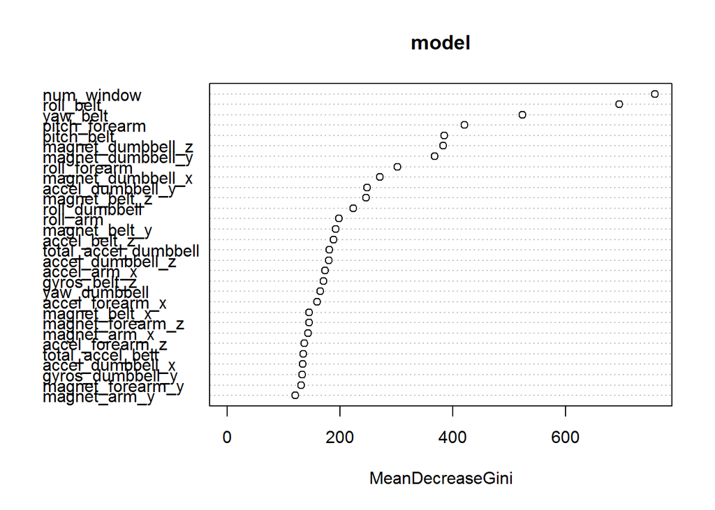

```r
model <- randomForest(classe~., data=subTraining,method='class',ntree=50)
varImpPlot(model)
```

# Evaluate the model on the training dataset

```r
pred=predict(model,subTesting, type='class')
z=confusionMatrix(pred,subTesting$classe)
```

#### The accuracy is shown below, which is more than 99% and it’s very impressive

```r
OverallAccuracy <- z$overall['Accuracy']
OverallAccuracy
```

```
##  Accuracy
## 0.9949019
```

### Let’s look at Confusion Matrix and Statistics

```r
z
```

```
## Confusion Matrix and Statistics
##
##           Reference
## Prediction    A    B    C    D    E
##          A 2231    5    0    0    0
##          B    1 1508    5    0    1
##          C    0    5 1363   18    0
##          D    0    0    0 1267    4
##          E    0    0    0    1 1437
##
## Overall Statistics
##
##                Accuracy : 0.9949
##                  95% CI : (0.9931, 0.9964)
##     No Information Rate : 0.2845
##     P-Value [Acc > NIR] : < 2.2e-16
##
##                   Kappa : 0.9936
##  Mcnemar's Test P-Value : NA
##
## Statistics by Class:
##
##                      Class: A Class: B Class: C Class: D Class: E
## Sensitivity            0.9996   0.9934   0.9963   0.9852   0.9965
## Specificity            0.9991   0.9989   0.9964   0.9994   0.9998
## Pos Pred Value         0.9978   0.9954   0.9834   0.9969   0.9993
## Neg Pred Value         0.9998   0.9984   0.9992   0.9971   0.9992
## Prevalence             0.2845   0.1935   0.1744   0.1639   0.1838
## Detection Rate         0.2843   0.1922   0.1737   0.1615   0.1832
## Detection Prevalence   0.2850   0.1931   0.1767   0.1620   0.1833
## Balanced Accuracy      0.9993   0.9962   0.9964   0.9923   0.9982
```

### Out-of-sample error rate

The Random Forest’s out-of-sample error rate is derived by the formula 100% - Accuracy

```r
1-OverallAccuracy
```

```
##    Accuracy
## 0.005098139
```